# Exploring Lok Sabha 2014 Candidates Data

Shardul Raghavendra Deolankar

28/01/2022

[figure not shown]

Trying to answer the following 20 questions:  
1. Total number of candidates that contested the election?  
2. What was the **Gender** composition of the candidates?  
3. What was the **Category** composition of the candidates?  
4. What is the age-group of maximum number of candidates?  
5. How many political parties contested the elections?  
6. **Top ten political parties** that contested most number of seats?  
7. What was the category distribution of the candidates by these ten political parties?  
8. What is the Gender composition of the candidates belonging to these parties?  
9. Who was the **oldest candidate**? Get all his Details  
10. Who was the **oldest woman**? Get all her details  
11. Which Political party won the **maximum number of seats**?  
12. Which state has the **highest number of constituencies**?  
13. In which state did BJP win the highest number of seats?  
14. What is the total **vote-share of BJP**?  
15. In which state did INC win the highest number of seats?  
16. What is the total **vote-share of INC**?  
17. Which candidate got the highest number of votes?  
18. Which candidate got the lowest number of votes?  
19. Which constituency had the **highest number of candidates**?  
20. In how many constituencies was **INC at second position**?

## **First Glance of the Data**

```r
df1 <- read.csv("LS2014Candidate.csv", stringsAsFactors = TRUE, na.strings = c("", NA, "NULL"))
head(df1)
```

```
##   ST_CODE     State.name Month Year PC.Number   PC.name PC.Type
## 1     S01 Andhra Pradesh     5 2014         1 Adilabad       ST
## 2     S01 Andhra Pradesh     5 2014         1 Adilabad       ST
## 3     S01 Andhra Pradesh     5 2014         1 Adilabad       ST
## 4     S01 Andhra Pradesh     5 2014         1 Adilabad       ST
## 5     S01 Andhra Pradesh     5 2014         1 Adilabad       ST
## 6     S01 Andhra Pradesh     5 2014         1 Adilabad       ST
##      Candidate.Name Candidate.Sex Candidate.Category Candidate.Age
## 1      GODAM NAGESH             M                 ST            49
## 2            NARESH             M                 ST            37
## 3     RAMESH RATHOD             M                 ST            48
## 4   RATHOD SADASHIV             M                 ST            55
## 5  NETHAWATH RAMDAS             M                 ST            44
## 6 None of the Above          <NA>               <NA>            NA
##   Party.Abbreviation Total.Votes.Polled Position
## 1                TRS             430847        1
## 2                INC             259557        2
## 3                TDP             184198        3
## 4                BSP              94420        4
## 5                IND              41032        5
## 6               NOTA              17084        6
```

```r
summary(df1)
```

```
##     ST_CODE              State.name       Month        Year
##  S24    :1368   Uttar Pradesh :1368   Min.   :5   Min.   :2014
##  S13    : 945   Maharashtra   : 945   1st Qu.:5   1st Qu.:2014
##  S22    : 884   Tamil Nadu    : 884   Median :5   Median :2014
##  S04    : 647   Bihar         : 647   Mean   :5   Mean   :2014
##  S01    : 640   Andhra Pradesh: 640   3rd Qu.:5   3rd Qu.:2014
##  S25    : 514   West Bengal   : 514   Max.   :5   Max.   :2014
##  (Other):3796   (Other)       :3796
##    PC.Number              PC.name     PC.Type              Candidate.Name
##  Min.   : 1.00   Chennai South:  43   GEN:7141   None of the Above: 543
##  1st Qu.: 7.00   Varanasi     :  43   SC :1138   ANIL KUMAR       :  11
##  Median :15.00   Aurangabad   :  42   SC :  15   ASHOK KUMAR      :  10
##  Mean   :19.52   Hisar        :  42   ST : 500   VIJAY KUMAR      :   9
##  3rd Qu.:28.00   Chennai North:  41              MANOJ KUMAR      :   7
##  Max.   :80.00   Beed         :  40              RAJESH KUMAR     :   7
##                  (Other)      :8543              (Other)          :8207
##  Candidate.Sex Candidate.Category Candidate.Age   Party.Abbreviation
##  F   : 668     Gen :   1          Min.   :25.00   IND    :3234
##  M   :7578     GEN :5532          1st Qu.:38.00   NOTA   : 543
##  O   :   6     SC  :2098          Median :46.00   BSP    : 503
##  NA's: 542     ST  : 621          Mean   :47.15   INC    : 464
##                NA's: 542          3rd Qu.:56.00   AAAP   : 432
##                                   Max.   :93.00   BJP    : 428
##                                   NA's   :542     (Other):3190
##  Total.Votes.Polled    Position
##  Min.   :   105     Min.   : 1.000
##  1st Qu.:  1762     1st Qu.: 5.000
##  Median :  4519     Median : 9.000
##  Mean   : 62975     Mean   : 9.788
##  3rd Qu.: 15225     3rd Qu.:13.000
##  Max.   :863358     Max.   :43.000
##
```

It can be seen that this data contains independent candidates as well as the None of the above option for each constituency.

### Question 1: Total number of candidates that contested the election?

```r
df_updated <- df1[-which(df1$Candidate.Name == "None of the Above"), ]
write.csv(df_updated, "Updated_df.csv")
#nota <- length(which(df1$Candidate.Name == "None of the Above"))
df1 <- read.csv("Updated_df.csv", stringsAsFactors = TRUE, na.strings = c("", NA, "NULL"))
num_candidates <- length(df1$Candidate.Name)
print(paste("The total number of candidates that contested the 2014 Lok Sabha Elections are", num_candidates))
```

```
## [1] "The total number of candidates that contested the 2014 Lok Sabha Elections are 8251"
```

### Question 2: What was the **Gender** composition of the candidates?

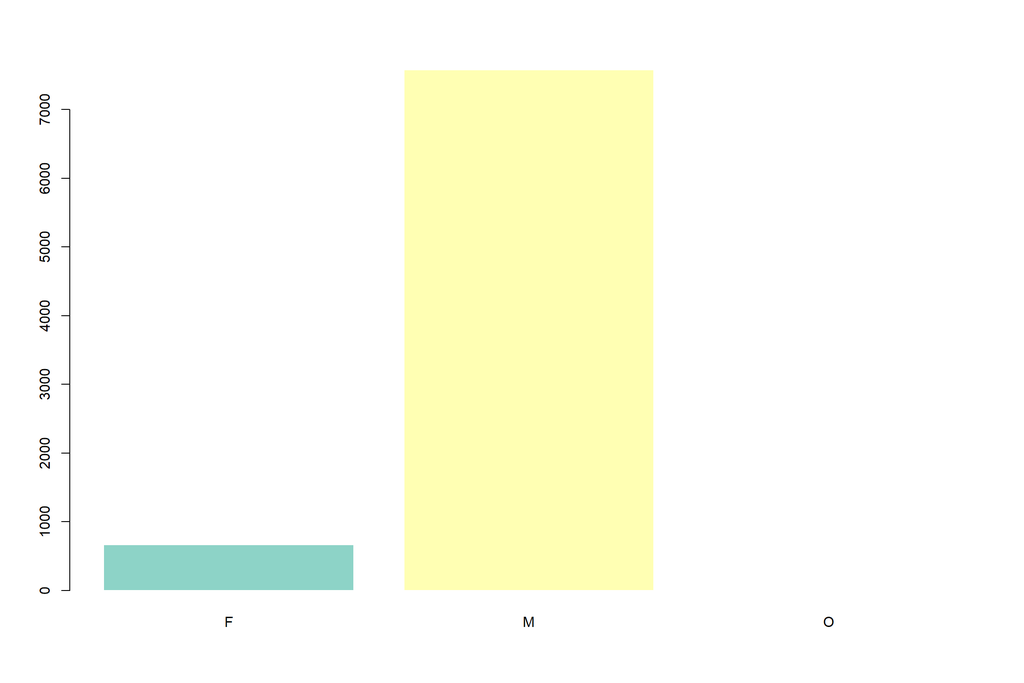

```r
library(RColorBrewer)
df2 <- subset(df1, Candidate.Name != "None of the Above")
gender <- as.table(table(df_updated$Candidate.Sex))
barplot(gender, col = brewer.pal(n = 2, name = "Set3"), border = "White")
```

```r
prop.table(gender)
```

```
##
##            F            M            O
## 0.0809598837 0.9183129318 0.0007271846
```

### Question 3: What was the **Category** composition of the candidates?

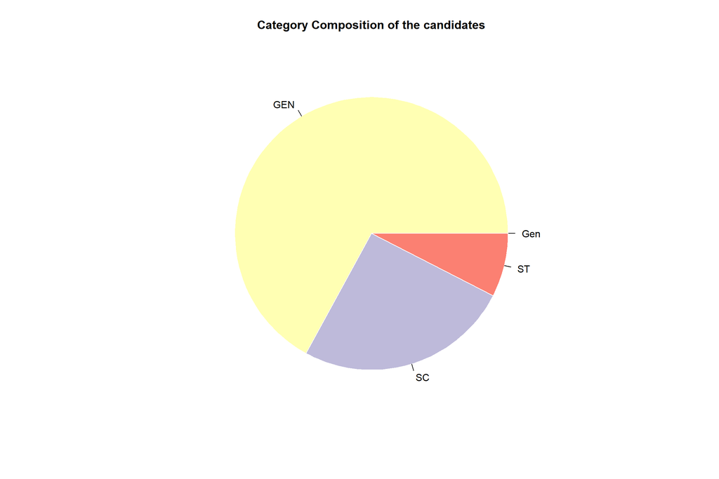

```r
category <- as.table(table(df2$Candidate.Category))
pie(category, main = "Category Composition of the candidates", col = brewer.pal(n = length(df2$Candidate.Category), name = "Set3"), border = "White")
```

```r
prop.table(category)
```

```
##
##          Gen          GEN           SC           ST
## 0.0001211974 0.6703429887 0.2542722094 0.0752636044
```

### Question 4: What is the age-group of maximum number of candidates?

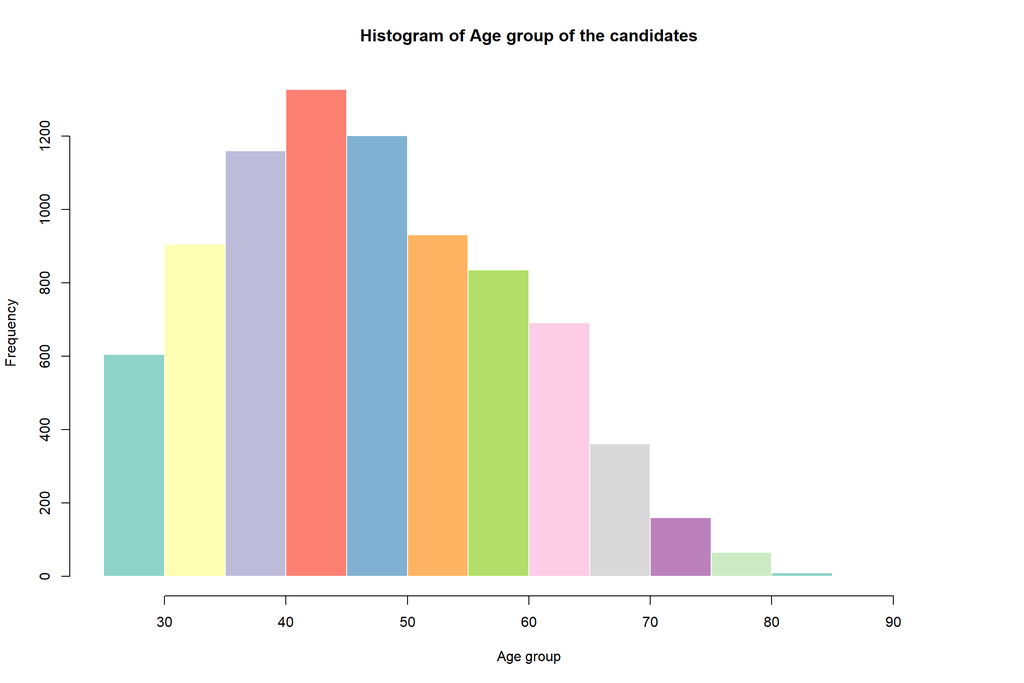

```r
hist(as.numeric(as.character(df2$Candidate.Age)), main = paste("Histogram of Age group of the candidates"), xlab = "Age group", col = brewer.pal(n = 11, name = "Set3"), border = "white", density = 100, angle = 0)
```

This shows that the maximum candidates belong to the age group of 40-45 years.

### Question 5: How many political parties contested the elections?

```r
parties <- table(df2$Party.Abbreviation)
print(paste(length(parties) - 1, "parties contested the elections"))
```

```
## [1] "464 parties contested the elections"
```

### Question 6: Top ten political parties that contested most number of seats?

```r
summary(df2$Party.Abbreviation, maxsum = 12)
```

```
##        IND        BSP        INC       AAAP        BJP       BMUP         SP
##       3234        503        464        432        428        233        197
##       AITC        CPM      JD(U) CPI(ML)(L)    (Other)
##        131         93         93         82       2361
```

The top 10 political parties were BSP, INC, AAAP, BJP. BMUP, SP, AITC, CPM, JD(U), CPI(ML) (IND stands for independent, hence not included)

### Question 7: What was the category distribution of the candidates by these ten political parties?

```r
df3 <- subset(df2, df2$Party.Abbreviation == "BSP")
df4 <- subset(df2, df2$Party.Abbreviation == "INC")
df5 <- subset(df2, df2$Party.Abbreviation == "AAAP")
df6 <- subset(df2, df2$Party.Abbreviation == "BJP")
df7 <- subset(df2, df2$Party.Abbreviation == "BMUP")
df8 <- subset(df2, df2$Party.Abbreviation == "AITC")
df9 <- subset(df2, df2$Party.Abbreviation == "CPM")
df10 <- subset(df2, df2$Party.Abbreviation == "JD(U)")
df11 <- subset(df2, df2$Party.Abbreviation == "SP")
df12 <- subset(df2, df2$Party.Abbreviation == "CPI(ML)(L)")


df13 <- rbind(df3, df4, df5, df6, df7, df8, df9, df10, df11, df12)
xtabs(~Party.Abbreviation+Candidate.Category, data = df13, addNA = FALSE, drop.unused.levels = TRUE)
```

```
##                   Candidate.Category
## Party.Abbreviation GEN  SC  ST
##         AAAP       333  65  34
##         AITC       101  17  13
##         BJP        318  64  46
##         BMUP       102 110  21
##         BSP        242 216  45
##         CPI(ML)(L)  52  20  10
##         CPM         65  16  12
##         INC        337  78  49
##         JD(U)       70  12  11
##         SP         153  36   8
```

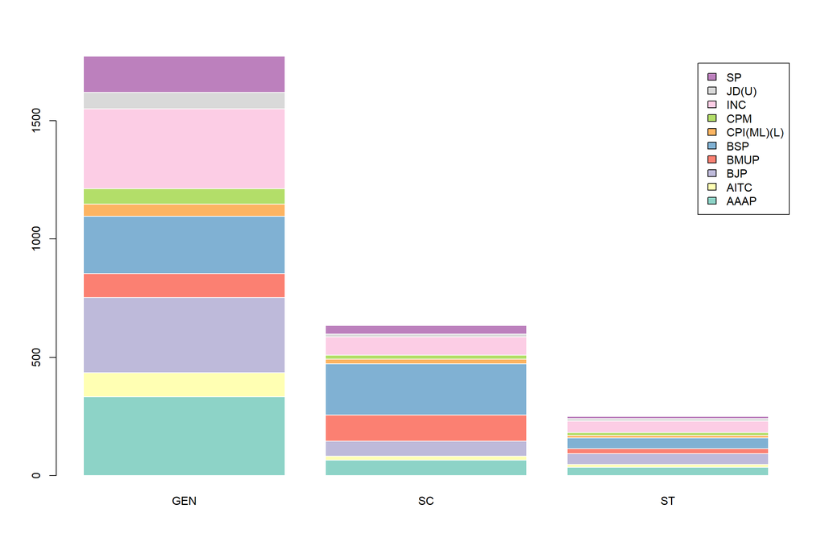

```r
table2 <- xtabs(~Party.Abbreviation+Candidate.Category, data = df13, addNA = FALSE, drop.unused.levels = TRUE)
barplot(table2, legend.text = TRUE, col = brewer.pal(n = 10, name = "Set3"), border = "White")
```

### Question 8: What is the Gender composition of the candidates belonging to these parties?

```r
xtabs(~Party.Abbreviation+Candidate.Sex, data = df13, addNA = FALSE, drop.unused.levels = TRUE)
```

```
##                   Candidate.Sex
## Party.Abbreviation   F   M
##         AAAP        59 373
##         AITC        25 106
##         BJP         38 390
##         BMUP         9 224
##         BSP         27 476
##         CPI(ML)(L)  10  72
##         CPM         11  82
##         INC         60 404
##         JD(U)        5  88
##         SP          29 168
```

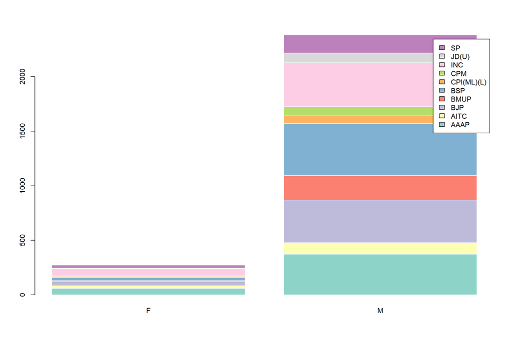

```r
table3 <- xtabs(~Party.Abbreviation+Candidate.Sex, data = df13, addNA = FALSE, drop.unused.levels = TRUE)
barplot(table3, legend.text = TRUE,  col = brewer.pal(n = 10, name = "Set3"), border = "White")
```

### Question 9: Who was the oldest candidate? Get all his Details

```r
df2[which.max(as.numeric(as.character(df2$Candidate.Age))), ]
```

```
##         X ST_CODE State.name Month Year PC.Number      PC.name PC.Type
## 1078 1156     S04      Bihar     5 2014        21 Hajipur (SC)      SC
##      Candidate.Name Candidate.Sex Candidate.Category Candidate.Age
## 1078 RAM SUNDAR DAS             M                 SC            93
##      Party.Abbreviation Total.Votes.Polled Position
## 1078              JD(U)              95790        3
```

### Question 10: Who was the oldest woman? Get all her details

```r
df_woman <- subset(df2, df2$Candidate.Sex == "F")
df_woman[which.max(as.numeric(as.character(df_woman$Candidate.Age))), ]
```

```
##       X ST_CODE State.name Month Year PC.Number PC.name PC.Type
## 683 733     S03      Assam     5 2014         7 Gauhati     GEN
##         Candidate.Name Candidate.Sex Candidate.Category Candidate.Age
## 683 BIJOYA CHAKRAVARTY             F                GEN            75
##     Party.Abbreviation Total.Votes.Polled Position
## 683                BJP             764985        1
```

### Question 11: Which Political party won the maximum number of seats?

```r
df_max_seats <- subset(df2, df2$Position == "1")
summary(df_max_seats$Party.Abbreviation, maxsum = 10)
```

```
##     BJP     INC    ADMK    AITC     BJD     SHS     TDP     TRS     CPM (Other)
##     282      44      37      34      20      18      16      11       9      72
```

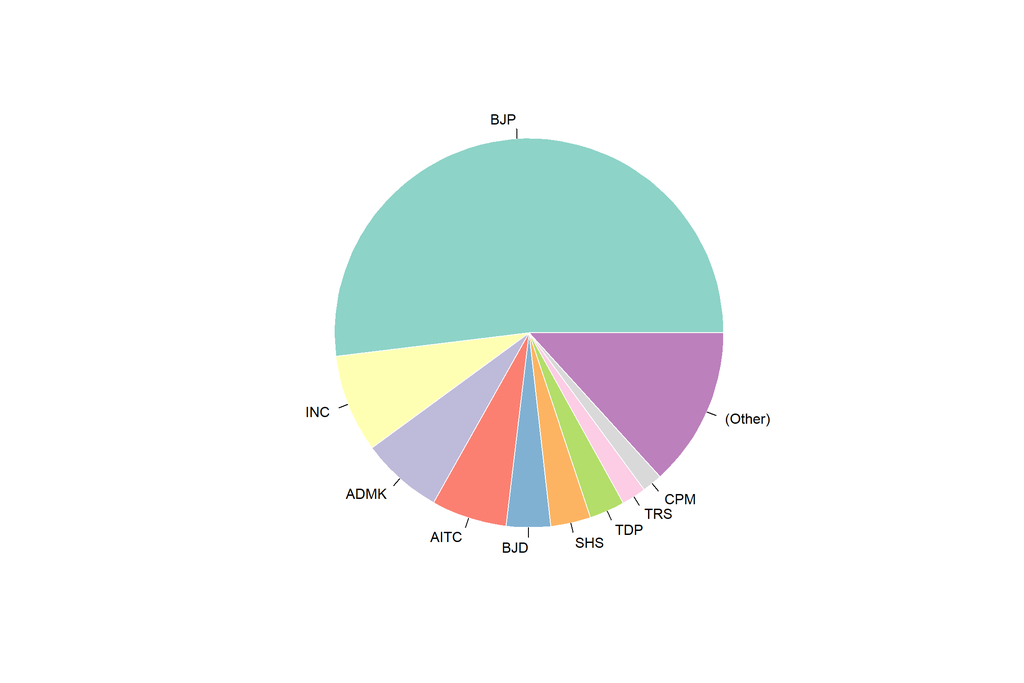

```r
max_table <- table(summary(df_max_seats$Party.Abbreviation, maxsum = 10))

pie(summary(df_max_seats$Party.Abbreviation, maxsum = 10),  col = brewer.pal(n = 11, name = "Set3"), border = "White")
```

### Question 12: Which state has the highest number of constituencies?

```r
summary(df_max_seats$State.name, maxsum = 7)
```

```
##  Uttar Pradesh    Maharashtra Andhra Pradesh    West Bengal          Bihar
##             80             48             42             42             40
##     Tamil Nadu        (Other)
##             39            252
```

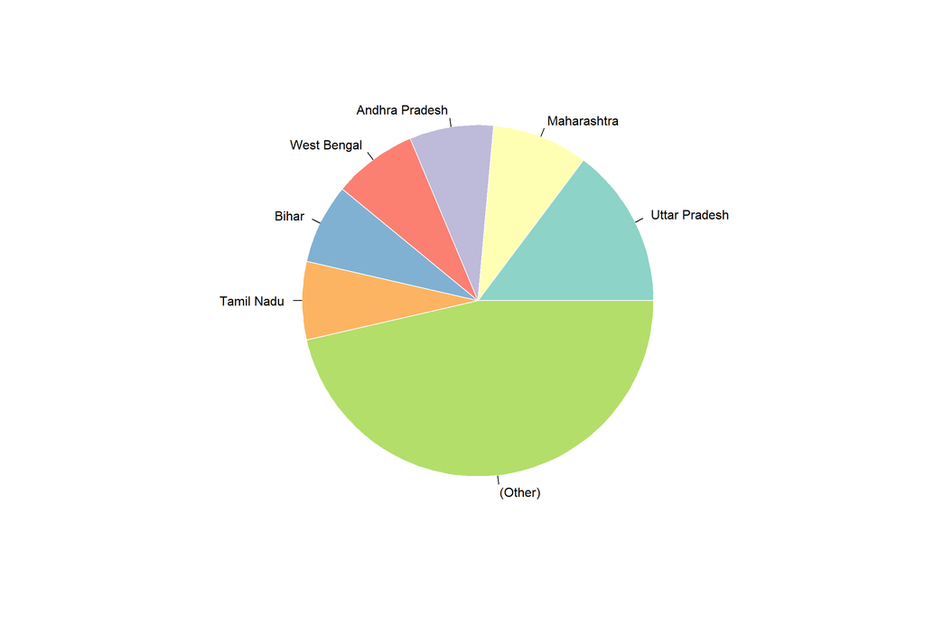

```r
pie(summary(df_max_seats$State.name, maxsum = 7),  col = brewer.pal(n = 7, name = "Set3"), border = "White")
```

### Question 13: In which state did BJP win the highest number of seats?

```r
df_max_bjp <- subset(df_max_seats, df_max_seats$Party.Abbreviation == "BJP")
summary(df_max_bjp$State.name, maxsum = 10)
```

```
##  Uttar Pradesh Madhya Pradesh        Gujarat      Rajasthan    Maharashtra
##             71             27             26             25             23
##          Bihar      Karnataka      Jharkhand    Chattisgarh        (Other)
##             22             17             12             10             49
```

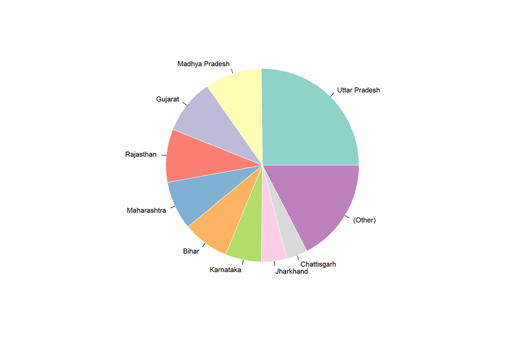

```r
pie(summary(df_max_bjp$State.name, maxsum = 10),  col = brewer.pal(n = 10, name = "Set3"), border = "White")
```

### Question 14: What is the total vote-share of BJP?

```r
total_votes <- sum(df2$Total.Votes.Polled)
df_bjp <- subset(df2, df2$Party.Abbreviation == "BJP")
total_votes_bjp <- sum(df_bjp$Total.Votes.Polled)
share <- round(total_votes_bjp/total_votes, 4)
print(paste(share * 100, "%"))
```

```
## [1] "31.34 %"
```

### Question 15: In which state did INC win the highest number of seats?

```r
df_max_inc <- subset(df_max_seats, df_max_seats$Party.Abbreviation == "INC")
summary(df_max_inc$State.name, maxsum = 10)
```

```
##      Karnataka         Kerala    West Bengal          Assam         Punjab
##              9              8              4              3              3
## Andhra Pradesh          Bihar Madhya Pradesh    Maharashtra        (Other)
##              2              2              2              2              9
```

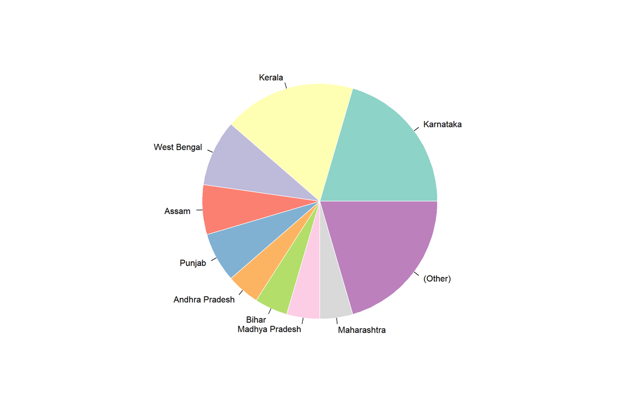

```r
pie(summary(df_max_inc$State.name, maxsum = 10),  col = brewer.pal(n = 10, name = "Set3"), border = "White")
```

### Question 16: What is the total vote-share of INC?

```r
total_votes <- sum(df2$Total.Votes.Polled)
df_inc <- subset(df2, df2$Party.Abbreviation == "INC")
total_votes_inc <- sum(df_inc$Total.Votes.Polled)
share <- round(total_votes_inc/total_votes, 4)
print(paste(share * 100, "%"))
```

```
## [1] "19.52 %"
```

### Question 17: Which candidate got the highest number of votes?

```r
df2[which.max(df2$Total.Votes.Polled), ]
```

```
##         X ST_CODE State.name Month Year PC.Number PC.name PC.Type
## 4614 4931     S20  Rajasthan     5 2014         7  Jaipur     GEN
##        Candidate.Name Candidate.Sex Candidate.Category Candidate.Age
## 4614 RAMCHARAN BOHARA             M                GEN            56
##      Party.Abbreviation Total.Votes.Polled Position
## 4614                BJP             863358        1
```

### Question 18: Which candidate got the lowest number of votes?

```r
df2[which.min(df2$Total.Votes.Polled), ]
```

```
##         X ST_CODE State.name Month Year PC.Number       PC.name PC.Type
## 4959 5299     S22 Tamil Nadu     5 2014         3 Chennai South     GEN
##      Candidate.Name Candidate.Sex Candidate.Category Candidate.Age
## 4959   S. VEERAMANI             M                GEN            63
##      Party.Abbreviation Total.Votes.Polled Position
## 4959                IND                105       43
```

### Question 19: Which constituency had the highest number of candidates?

```r
summary(df2$PC.name, maxsum = 2)
```

```
## Chennai South       (Other)
##            42          8209
```

### Question 20: In how many constituencies was INC at second position?

```r
df_second <- subset(df2, df2$Position == "2")
df_second_inc <- df_second[df_second$Party.Abbreviation == "INC", ]
nrow(df_second_inc)
```

```
## [1] 224
```